# Understanding Methane and Carbon Dioxide Fluxes in the Mackenzie River Delta

June Skeeter<sup>1</sup>, Peter Morse<sup>1</sup>

1. Geological Survey of Canada, Natural Resources Canada

2025-05-07

## Overview

The Mackenzie River Delta in the Northwest Territories is the Arctic’s second largest river delta and is of particular concern with regard to methane emissions because methane hotspots” have been detected by multiple aerial surveys, which are attributable to geologic methane seeps and/or to biologic methane emissions from its expansive wetland areas, both of which have the potential to increase with permafrost degradation due to climate change.<sup>1</sup><sup>2</sup><sup>3</sup>

## Background

Eddy covariance (EC) is one of the primary methods to monitor landscape-scale greenhouse gas exchange and understand the dynamics controlling gas exchange over time.

- The method involves measuring high-frequency (10-20 Hz) 3-D wind velocity and gas concentrations.
- Given assumptions are met (e.g., stationary) high frequency data are processed to estimate mean half-hourly flux densities.

### Limited Arctic Flux Observations

There is sparse coverage of EC stations in the Arctic, outside of Scandinavia and Alaska as shown in Figure 1.

- EC stations are are difficult to opperate in remote environments due to maintenance and power demands.
- Sites measuring CH<sub>4</sub> are even less common.

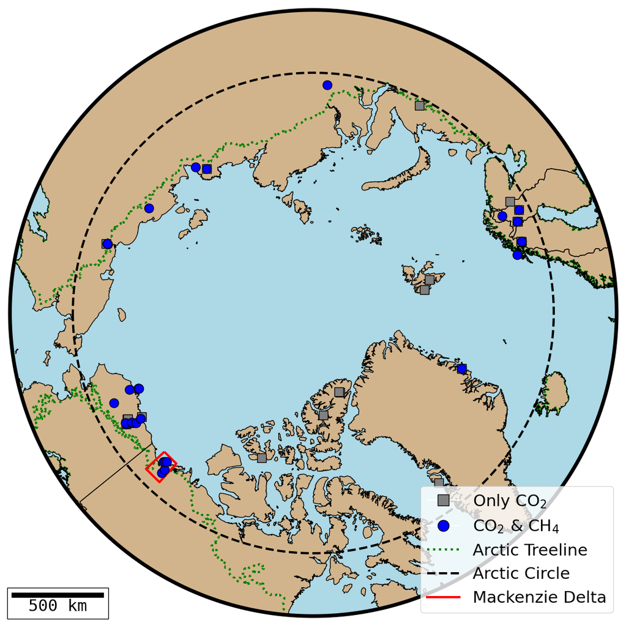

Figure 1: Eddy covariance sites above of 60°N with at least one season of data.<sup>4</sup> *Note* Many of the sites shown are no longer active.

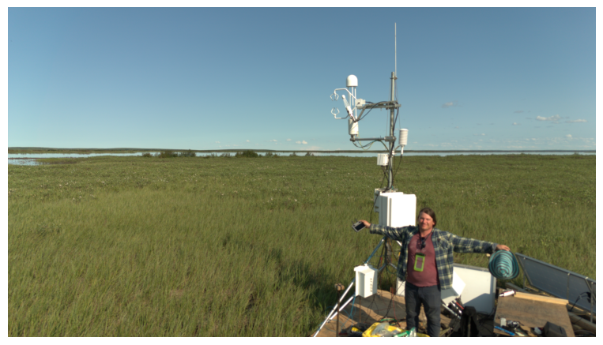

Figure 2: Eddy covariance system with open path CO<sub>2</sub> and CH<sub>4</sub> sensors.

## Study Sites

The Mackenzie River Delta and surrounding upland terrain are shown in Figure 3.

- The region straddles the treeline and has a complex geologic history.
- The region is the only part of the Canadian Arctic with road access.

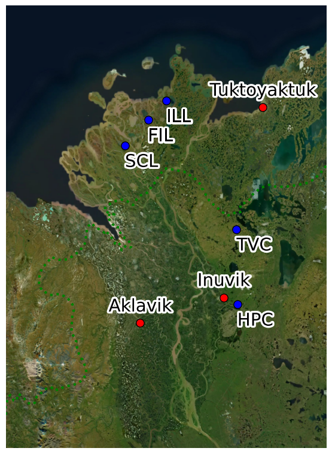

Figure 3: Eddy covariance sites and communities in the Mackenzie Delta Region. Map corresponds to the inset in Figure 1

To reduce the uncertainties regarding the trajectory of greenhouse gas fluxes in the delta, an EC system was installed in mid-summer 2024 at a sedge wetland site underlain by thin continuous permafrost which is representative of the outer delta area.

The system measures the ecosystem-atmosphere exchange of methane and carbon dioxide and collects ancillary data that include solar radiation, air temperature, soil temperature profiles, and water table depth. These data are used to understand the functional relationships driving greenhouse gas fluxes in the region and to estimate the greenhouse gas balance of the region. The 2024 field season was an exploratory campaign, limited from the mid-July to mid-September using borrowed EC instrumentation. A longer-term, multi-year campaign is planned to begin in June 2025 with the installation of newly procured EC sensors.

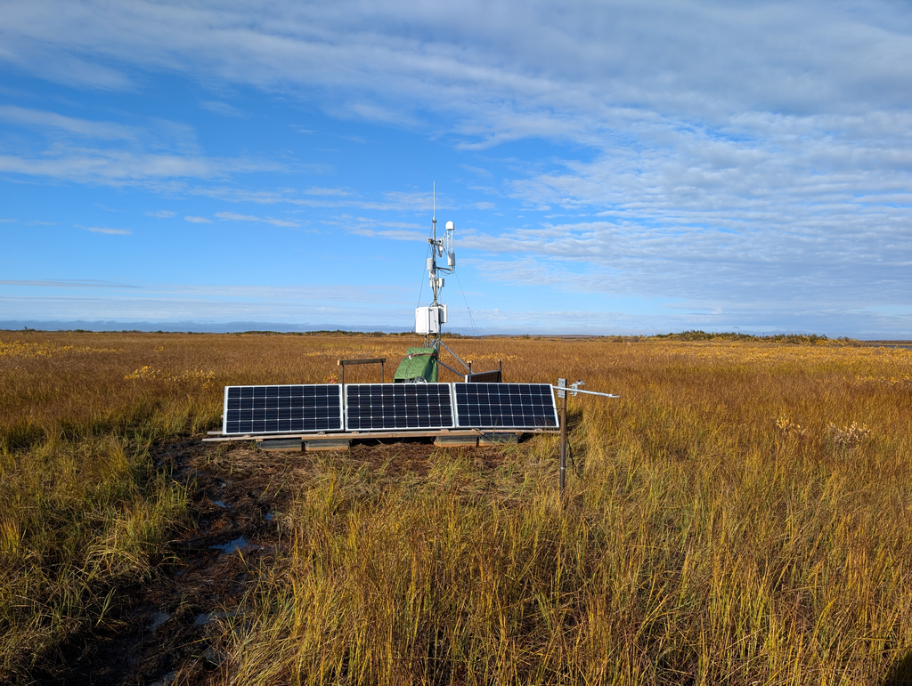

## References

1.

Kohnert, K., Serafimovich, A., Metzger, S., Hartmann, J. & Sachs, T. Strong geologic methane emissions from discontinuous terrestrial permafrost in the Mackenzie Delta, Canada. *Scientific Reports* **7**, 1–6 (2017).

2.

Skeeter, J., Christen, A. & Henry, G. H. R. Controls on carbon dioxide and methane fluxes from a low-center polygonal peatland in the Mackenzie River Delta, Northwest Territories. *Arctic Science* **8**, 471–497 (2022).

3.

Wesley, D., Dallimore, S., MacLeod, R., Sachs, T. & Risk, D. Characterization of atmospheric methane release in the outer Mackenzie River delta from biogenic and thermogenic sources. *The Cryosphere* **17**, 5283–5297 (2023).

4.

Pallandt, M. *et al.* Representativeness assessment of the pan-Arctic eddy-covariance site network, and optimized future enhancements. *Biogeosciences Discussions* 1–42 (2021).